# Reproducible Research Course Project2: Harm and damage caused by major weather events

- Synopsis: Major weather events cause both harm to individuals and damage to property. National Weather Service data from 1950 to 2011 was analyzed to determine which event types caused the most damage.  
  This is an [R Markdown](http://rmarkdown.rstudio.com) Notebook. When you execute code within the notebook, the results appear beneath the code.
- data prep: Raw data is pulled from repdata_data_StormData.csv.bz2.

Harm is calculated by adding up both injury and fatality counts per event. This data is mostly zeros with a right skew. I attempted to log transform the data but this did not help normalize the data, so I resorted to just using sum counts for analysis of greatest harm. When comparing harm between different event types I filtered out all minor event.

Property damage data can be normalized fairly well with a log transformation.

```r
propDamageFiltered <- function(val, exp) {
    returnVal <- val  # default
    if (exp=="K") {
        returnVal <- val * 1000
    }
    else if (exp =="M" | exp =="m") {
        returnVal <- val * 1000000
    }
    else if (exp == "B") {
        returnVal <- val * 1000000000
    }
    returnVal
}
# 1. Code for reading in the dataset and/or processing the data
library(utils)
# read in data
# 10. Does the analysis start from the raw data file (i.e. the original .csv.bz2 file)?
print("reading in raw data...")
```

```
[1] "reading in raw data..."
```

```r
#df <- read.csv(".\\repdata_data_StormData.csv.bz2", na.strings = NA)
print("done reading in raw data.")
```

```
[1] "done reading in raw data."
```

```r
# transform data
df$InjuriesPlusFatalities <- df$FATALITIES + df$INJURIES
df$logInjuriesPlusFatalities <- log(df$InjuriesPlusFatalities + 1)
df$logFatalities <- log(df$FATALITIES + 1)
df$logInjuries <- log(df$INJURIES + 1)
df$propDamageFiltered <- propDamageFiltered(df$PROPDMG, df$PROPDMGEXP)
```

```
the condition has length > 1 and only the first element will be used
```

```r
df$logPropDamageFiltered <- log(df$propDamageFiltered)
```

‘Harm’ in this report refers to the aggregate of “INJURIES” and “FATALITIES”. To assess greatest ‘HARM’ the raw data was aggregated for each event type into summary tables.

```r
# aggregate data into summary tables
print("building summary tables...")
```

```
[1] "building summary tables..."
```

```r
totalFatalities <- aggregate(df$FATALITIES, list(factor(df$EVTYPE)), sum)
names(totalFatalities) <- c("EVTYPE", "FATALITIES")
totalFatalities <- totalFatalities[totalFatalities$FATALITIES >0,]
totalFatalities$logFatalities <- log(totalFatalities$FATALITIES + 1)

totalInjuries <- aggregate(df$INJURIES, list(factor(df$EVTYPE)), sum)
names(totalInjuries) <- c("EVTYPE", "INJURIES")
totalInjuries <- totalInjuries[totalInjuries$INJURIES>0,]
totalInjuries$logInjuries <- log(totalInjuries$INJURIES + 1)

totalInjuriesPlusFatalities <- aggregate(df$InjuriesPlusFatalities, list(factor(df$EVTYPE)), sum)
names(totalInjuriesPlusFatalities) <- c("EVTYPE", "InjuriesPlusFatalities")
totalInjuriesPlusFatalities <- totalInjuriesPlusFatalities[totalInjuriesPlusFatalities$InjuriesPlusFatalities>0,]
totalInjuriesPlusFatalities$logInjuriesPlusFatalities <- log(totalInjuriesPlusFatalities$InjuriesPlusFatalities + 1)

totalPropertyDamage <- aggregate(df$propDamageFiltered,
                                 list(factor(df$EVTYPE)), sum)
names(totalPropertyDamage) <- c("EVTYPE", "totalPropDamage")
totalPropertyDamage <- totalPropertyDamage[totalPropertyDamage$totalPropDamage>0,]
totalPropertyDamage$logTotalPropDamage <- log(totalPropertyDamage$totalPropDamage + 1)
print("done building summary tables.")
```

```
[1] "done building summary tables."
```

```
Pareto chart analysis for paretoTotal$InjuriesPlusFatalities
       Frequency    Cum.Freq.   Percentage Cum.Percent.
  L 9.697900e+04 9.697900e+04 6.809128e+01 6.809128e+01
  A 8.428000e+03 1.054070e+05 5.917500e+00 7.400878e+01
  M 7.461000e+03 1.128680e+05 5.238547e+00 7.924732e+01
  C 7.259000e+03 1.201270e+05 5.096718e+00 8.434404e+01
  J 6.046000e+03 1.261730e+05 4.245041e+00 8.858908e+01
  E 3.037000e+03 1.292100e+05 2.132350e+00 9.072143e+01
  B 2.755000e+03 1.319650e+05 1.934351e+00 9.265578e+01
  I 2.064000e+03 1.340290e+05 1.449184e+00 9.410497e+01
  K 1.621000e+03 1.356500e+05 1.138143e+00 9.524311e+01
  N 1.527000e+03 1.371770e+05 1.072143e+00 9.631525e+01
  G 1.385000e+03 1.385620e+05 9.724416e-01 9.728770e+01
  D 1.376000e+03 1.399380e+05 9.661225e-01 9.825382e+01
  H 1.339000e+03 1.412770e+05 9.401439e-01 9.919396e+01
  F 1.148000e+03 1.424250e+05 8.060383e-01 1.000000e+02
```

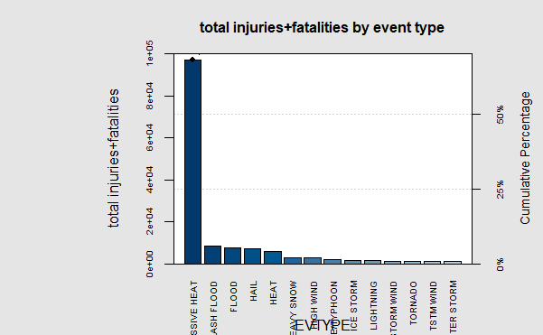

```r
# pareto of total fatalities+injuries by EVTYPE
par(mfrow=c(1,1), mar=c(4,10,2,1), cex.axis=0.6, las=2)
paretoTotal <- totalInjuriesPlusFatalities[totalInjuriesPlusFatalities$InjuriesPlusFatalities>1000,]
pareto.chart(paretoTotal$InjuriesPlusFatalities, ylim=c(0,100000),
             xlab="EVTYPE", ylab="total injuries+fatalities",
             main="total injuries+fatalities by event type",
             names.arg=paretoTotal$EVTYPE)
```

To compare the amount of harm per event, first I filtered out any minor events that had less than 200 injuries+fatalities reported, then plotted a boxplot, which shows that ice storms have the highest average harm inflicted, but the event counts appear to be low. The highest harm on any one event appears to be from one Tornado.

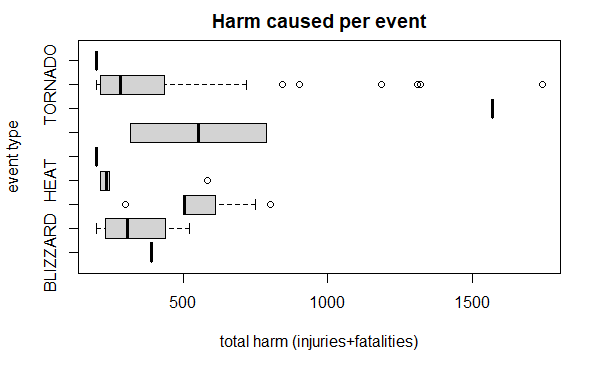

```r
# filter out minor events to compare fatalities + injuries per event
majorEvents <- df[df$InjuriesPlusFatalities>200,]
boxplot(InjuriesPlusFatalities ~ EVTYPE, data=majorEvents,
        horizontal=TRUE, main="Harm caused per event",
        ylab="event type", xlab="total harm (injuries+fatalities)")
```